# Hypothesis Testing Applied to Means

Tehran Davis  
9/26/2017

### Recap and revisit:

Imagine we have this population:

```
[1] "Mean = 1000.37 SD = 434.09"
```

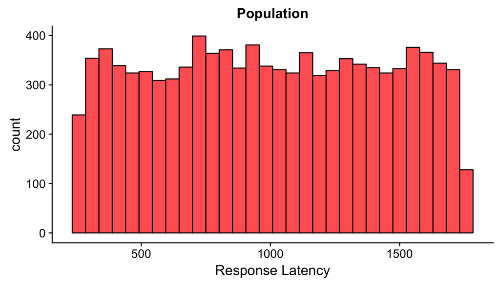

### Recap and revisit:

- sampling error (variability due to chance)

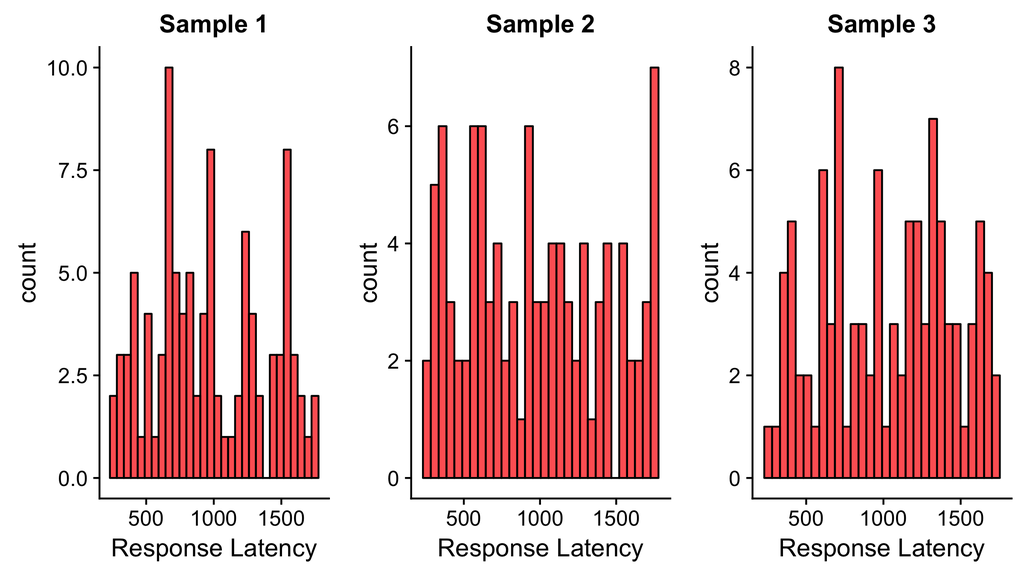

### Recap and revisit:

- the sampling distribution of means

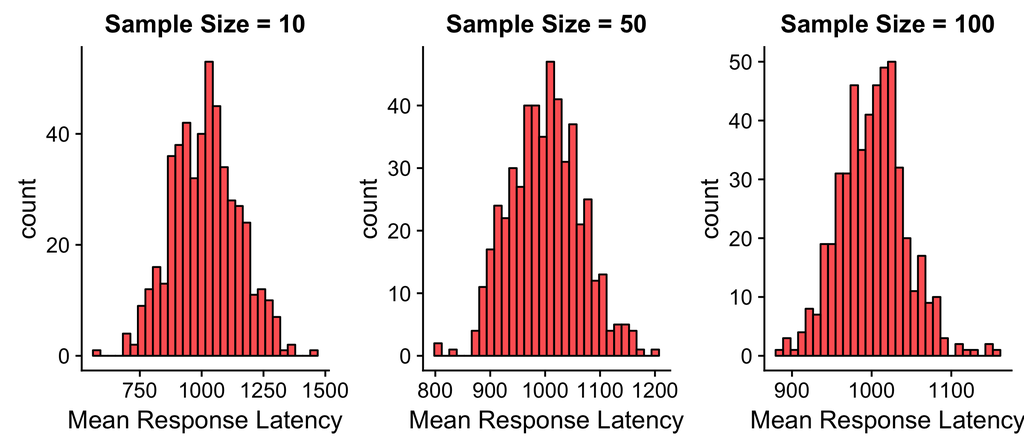

```
[1] "1014.94335846569 ± 133.917404744525 ; 1000.86956153315 ± 64.1757807416151 ; 1001.77035335508 ± 41.9854797777419 ;"
```

### Testing Hypotheses about Means

The central limit theorem provides a foundation for us to test hypothesis about means. It provides us with a way of ‘estimating’ what variation we would expect based on our sample size.

That is, we can use the SD of the sampling distribution of the mean, referred to as the standard error of the mean (SEM) to determine what is statistically probable or not.

\[ \sigma_\overline{X} = \frac{\sigma}{\sqrt{n}} \]

### Testing Hypotheses about Means (Z-scores)

We can use a Z-score when \( \mu \) and \( \sigma \) are known.

\[ Z = \frac{\overline{X} - \mu}{\sigma_\overline{X}} \]

where:

\( \overline{X} \) is the **sample mean**  
\( \mu \) is the **population mean**  
\( \sigma_\overline{X} \) is the **standard error of the mean**

**THIS YOU HAVE DONE!!!**

### Z examples (1/2)

suppose **\( \mu \) = 75** and **\( \sigma \) = 18**

\( H_0: \mu_\overline{X} = \mu \) \( H_1: \mu_\overline{X} ≠ \mu \)

**Sample mean = 80**

```r
z <- (80 - 75) / (18 / sqrt(25))
p <- 1 - pnorm(z,lower.tail = T)
show(c(z,p))
```

```
[1] 1.38888889 0.08243327
```

If alpha = .05, **DO NOT** reject \( H_0 \) if one-tailed test or if 2-tailed test (\( \alpha \)/2)

### Z examples (2/2)

suppose **\( \mu \) = 75** and **\( \sigma \) = 18**

\( H_0: \mu_\overline{X} = \mu \) \( H_1: \mu_\overline{X} ≠ \mu \) **Sample mean = 81**

```r
z <- (81 - 75) / (18 / sqrt(25))
p <- 1 - pnorm(z,lower.tail = T)
show(c(z,p))
```

```
[1] 1.66666667 0.04779035
```

If alpha = .05, **DO** reject \( H_0 \) if one-tailed test, but **DO NOT** for 2-tailed test (\( \alpha \)/2)

### Hypothesis testing using the Student’s t Distribution

z-test requires knowledge of parameters (i.e., σ)– which we don’t usually know. t-tests are statistical tests that estimate population parameters from a sample (i.e., σ from s) and, assuming a normal distribution, test hypothesis using a t statistic (rather than a z statistic) and the student’s t distribution.

Unlike the z distribution, the t distribution factors in the size of the sample distribution (i.e., n), because sampling distributions of sample variance tend to be positively skewed, especially for small sample sizes.

### Hypothesis testing using the Student’s t Distribution

The t-distribution accounts for this skewness and provides more accurate estimates of probability for hypothesis testing. The *df* determine how spread-out of a [t-distribution](https://gallery.shinyapps.io/tdist/) to use.

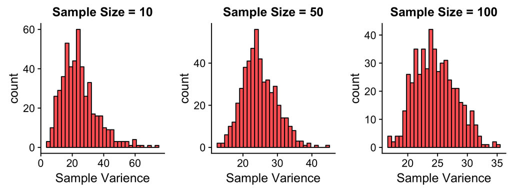

### One sample t-test

The **One-sample** test compares a sample to a known (set) mean.

\[ t = \frac{\overline{X} - \mu}{s_\overline{X}} \hspace{4cm} df = n-1 \]

where:

\( \overline{X} \) is the **sample mean**  
\( \mu \) is the **population mean**  
\( s_\overline{X} \) is the **standard error of the mean** \( \hspace{1cm} (s/\sqrt{n}) \)

### One sample t-test (Examples)

Suppose that **μ = 0** \( \hspace{1cm} \)&\( \hspace{1cm} \) **σ = ?**

\( H_0: \mu_\overline{X} = \mu \) \( H_1: \mu_\overline{X} ≠ \mu \)

**Example A. Sample Mean = 1.13, SD = 2.14, n = 15**

```r
t <- (1.13 - 0) / (2.14/sqrt(15))
p <- 1 - pt(q = t,df = 14)

show(c(t,p))
```

```
[1] 2.04507999 0.03006004
```

### One sample t-test (Examples)

Suppose that **μ = 0** \( \hspace{1cm} \)&\( \hspace{1cm} \) **σ = ?**

\( H_0: \mu_\overline{X} = \mu \) \( H_1: \mu_\overline{X} ≠ \mu \)

**Example B. Sample Mean = 1.56, SD = 2.14, n = 15**

```r
t <- (1.56 - 0) / (2.14/sqrt(15))
p <- 1 - pt(q = t,df = 14)

show(c(t,p))
```

```
[1] 2.823296271 0.006772244
```

### One sample t-test (Examples)

Assume a known distribution of GRE scores from UC:

- also a new trick to bring in the data (will only work on the fly!!)

we can bring in data copied from an Excel file and save to a data.frame:

```r
pacman::p_load(psych) # required package. The psych package is terribly useful!
ucGRE <- read.clipboard(header = F)
names(ucGRE) <- "ucGRE"

## if you copy from a clipboard you should immediately WRITE the data frame to a new file!!

#write.table(ucGRE,file = "ucGRE.txt", row.names = F)
```

### One sample t-test (Examples)

run the test

```r
ucGRE <- read.table("ucGRE.txt",header=T)
t.test(ucGRE,mu = 150,paired = F) # one-sample t.test
```

```
    One Sample t-test

data:  ucGRE
t = 2.3329, df = 19, p-value = 0.0308
alternative hypothesis: true mean is not equal to 150
95 percent confidence interval:
 150.4266 157.8734
sample estimates:
mean of x
   154.15
```

different variations

```r
? t.test
```

### Confidence Intervals

A **Confidence Interval** is an interval estimate of a population parameter and is used to indicate the reliability of an estimate within some degree of probability (usually 95% or 0.95). It is an observed interval (i.e. it is calculated from the observations), in principle different from sample to sample, that frequently includes the parameter of interest if the experiment is repeated. \[ CI_{0.95} = \overline{X} ± t_{critical}\ s_\overline{X} \]

The range of values \( CI_{lower} \) to \( CI_{upper} \) act as good estimates of the unknown population parameter.

### Matched sample t-test (repeated-measures)

Conceptually identical to a One-Sample Test. Here we create **difference scores** (\( score_1 \) - \( score_2 \))

Provided this data, run the test

```r
ucGRE_prepost <- read.table("https://raw.githubusercontent.com/tehjespah/tehjespah.github.io/master/GradStats_R/Week_6/Data/ucGRE_prepost.txt",header=T)
```

**NOTE**: first you'll need to create a vector of difference scores.

### Confidence Intervals and Effect Size

**Confidence interval** based on difference score: \[ CI_{0.95} = \overline{D} ± t_{critical}\ s_\overline{D} \]

**Effect Size:** Statistically significant does not mean “Large” or “important”. Effects size measures provide information about the size or relative “magnitude” of a significant effect.

**d-family:** effect size measures that provide information about differences.

**Cohen’s d:** provides a measure of effect size difference scaled to the SD of one of the samples or the average SD (choice depends on the alternative/research hypothesis).

### Calculating t and Cohen's d

```r
t.test(ucGRE_prepost$Pre.Study, ucGRE_prepost$Post.Study, paired = T)
```

```
    Paired t-test

data:  ucGRE_prepost$Pre.Study and ucGRE_prepost$Post.Study
t = -3.5522, df = 19, p-value = 0.002128
alternative hypothesis: true difference in means is not equal to 0
95 percent confidence interval:
 -4.37036 -1.12964
sample estimates:
mean of the differences
                  -2.75
```

```r
pacman::p_load(lsr)
cohensD(ucGRE_prepost$Pre.Study, ucGRE_prepost$Post.Study,method = "pooled")
```

```
[1] 0.3421813
```

### Independent samples t-test

\( \overline{X} \) is the **sample mean** 1 or 2 \( s_{\overline{X}_1 - \overline{X}_2} \) abides the rule that the variance of a sum or difference of two independent variables is equal to the sum of their variances.

This involves taking the **pooled variences**, a weighted average based on the size of each sample. Can account for different sample sizes if they exist (note: always better if you have equal samples sizes).

### Assumptions of the Independent or Between Groups t-test

- All the samples were randomly selected
- The measured variable is normally distributed in the population
- The samples are independent of each other.
- The standard deviations of the two samples are similar (homogeneity of variance)
- The two sample means represent measurements of the same dependent variable

### Independent or Between Groups t-test Example

Assuming we have a dataframe of UC v OSU grad student GRE scores (UCvOSU). We can compare scores between groups in two ways.

```r
UCvOSU <- read.table("https://raw.githubusercontent.com/tehjespah/tehjespah.github.io/master/GradStats_R/Week_6/Data/UCvOSU.txt", header=T)

head(UCvOSU)
```

```
  OH.State  UC
1      165 169
2      152 153
3      142 148
4      137 142
5      156 155
6      162 163
```

### Independent or Between Groups t-test Method 1

**Method 1: Enter each column of scores seperately**. This is similar to how we did the paired samples test earlier. EXCEPT note that the `paired` argument is set to `FALSE`. When calculating Cohen's d, I've elected to pool the SD's.

### Independent or Between Groups t-test Method 1 (code)

```r
t.test(UCvOSU$OH.State,UCvOSU$UC,paired = FALSE,var.equal = T)
```

```
    Two Sample t-test

data:  UCvOSU$OH.State and UCvOSU$UC
t = -1.0821, df = 38, p-value = 0.286
alternative hypothesis: true difference in means is not equal to 0
95 percent confidence interval:
 -7.894836  2.394836
sample estimates:
mean of x mean of y
   154.15    156.90
```

```r
cohensD(UCvOSU$OH.State,UCvOSU$UC,method = "pooled")
```

```
[1] 0.3421813
```

### Independent or Between Groups t-test Method 2

**Method 2: collapsing the data.frame and using a formula format:**

You can also collapse the data to a one-observation per row format using the `gather()` function from the `tidyr` package. This format is preferred in R, especially for things like ANOVA, Linear Regression, and may also be the required input for some functions in SPSS. Here, we create a new data frame `UCvOSU_alt` with the data in this format. We want to gather our scores from both columns into a single column (designated in the function by `value =`) and create a second column that identifies each score by the student's school (`key =`)

### Independent or Between Groups t-test Method 2 code

```r
pacman::p_load(tidyr)
UCvOSU_alt <- gather(data = UCvOSU,key = "school", value = "score")

## it may be useful to write your new, collapsed data.frame to a text file if you are sending to SPSS!!


#write.table(UCvOSU_alt, "https://raw.githubusercontent.com/tehjespah/tehjespah.github.io/master/GradStats_R/Week_6/Data/UCvOSU_alt.txt", row.names = F)
```

### Independent or Between Groups t-test Example

Comparing the original and new data frames:

```r
head(UCvOSU); head(UCvOSU_alt)
```

```
  OH.State  UC
1      165 169
2      152 153
3      142 148
4      137 142
5      156 155
6      162 163
```

```
    school score
1 OH.State   165
2 OH.State   152
3 OH.State   142
4 OH.State   137
5 OH.State   156
6 OH.State   162
```

### Independent or Between Groups t-test Example

And now running the t-test using the formual format. In this case we are looking at `score` as a function of `school`, or `score ~ school`.

```r
t.test(score~school,data=UCvOSU_alt, paired=F, var.equal=T)
```

```
    Two Sample t-test

data:  score by school
t = -1.0821, df = 38, p-value = 0.286
alternative hypothesis: true difference in means is not equal to 0
95 percent confidence interval:
 -7.894836  2.394836
sample estimates:
mean in group OH.State       mean in group UC
                154.15                 156.90
```

### Testing homogeneity of variance

In previous examples I've assumed that the variences of the two groups (OSU, UC) are equal when running my t.test. However, we should really test for this. A common method that is used is the Levene Test. This can be done in R using the `leveneTest()` function from the `car` package (another useful package, esp. for ANOVA). This is employed using the formula format as in the previous example.

### Testing homogeneity of variance code

```r
pacman::p_load(car)

leveneTest(score~school,data=UCvOSU_alt,center="mean")
```

```
Levene's Test for Homogeneity of Variance (center = "mean")
      Df F value Pr(>F)
group  1  0.3066  0.583
      38
```

The output of this test is an F value and a p value with the null hypothesis that the variences are equal. That is, if p < \( \alpha \) (typically .05) then we infer that the variences are unequal. If this is the case, you will need to run your `t.test` with `var.equal = FALSE`.